# World Development Data Project (Clustering, Regression, Classification)

## Case Description

This project is aiming to explore and classify countries based on their socio-economic development indicators while using supervised learning models. We want to make use of the cleaned dataset derived from the World Bank's development indicators, and in the following, perform various tasks to answer the relevant questions in three main areas (clustering, regression, and classification).

## Motivation

As we are an international group of students - and due some economics studies - we were inspired to look at the whole world and see what trends we can see, what lessons we can learn about the economic and environmental standings of various countries: what are the commonalities and what separates them, and might we gain some insight from our history and current standing on how we can further streer ourselves in the right direction when it comes to the economy, scoiety and the enviroment. To this end, we will analyize the socioeconomic and environment-related metrics found in our dataset as outlined in the following sections.

## Dataset Description

### Data Source:

World Bank Group DataBank: World Development Indicators (https://databank.worldbank.org/source/world-development-indicators)

Our starting data set contains the 23 selected indicators for all countries for the years 1985 to 2023. The indicators ("Series Name" in the dataset) loaded are as follows:

- GDP per capita, PPP (current international dollar)
- GDP growth (annual %)
- Gross fixed capital formation (% of GDP)
- Foreign direct investment, net inflows (% of GDP)
- Exports of goods and services (% of GDP)
- Imports of goods and services (% of GDP)
- Inflation, consumer prices (annual %)
- Unemployment, total (% of total labor force) (modeled ILO estimate)
- Labor force participation rate, female (% of female population ages 15+) (modeled ILO estimate)
- Gini
- Life expectancy at birth, total (years)
- Fertility rate, total (births per woman)
- School enrollment, tertiary (% gross)
- School enrollment, tertiary, female (% gross)
- Current health expenditure per capita (current US$)
- Current health expenditure (% of GDP)
- Individuals using the Internet (% of population)
- Mobile cellular subscriptions (per 100 people)
- Fixed broadband subscriptions (per 100 people)
- Carbon dioxide (CO2) emissions (total) excluding LULUCF (% change from 1990)
- Carbon dioxide (CO2) emissions (total) excluding LULUCF (Mt CO2e)
- Renewable energy consumption (% of total final energy consumption)
- Electric power consumption (kWh per capita)

The loaded dataset contains the following columns:

- Country Name
- Country Code
- Series Name
- Series Code [a unique idetified for the series]
- A column for each year

## The questions addressed in this notebook are:

**Clustering**

- Question 1: How can we discover hidden socioeconomic development based on trade openness (exports, imports), internet/mobile penetration, and tertiary enrolment?
- Question 2: Do countries cluster into distinct groups based on environmental and energy indicators (CO₂ emissions levels/trends, renewable energy % of use, and per capita energy consumption) along with economic size?
- Question 3: How have clusters changed over time? (revisiting the topics discussed in Questions 1 and 2)

**Regression**

- Question 1: What economic or social variables best predict lower inflation volatility across nations?
- Question 2: To what extent can internet access explain differences in fertility rates, controlling for female labour-force participation and education?
- Question 3: What factors predict the female labor force participation rate?
- Question 4: Do more open economies (with higher trade and investment relative to GDP) experience faster growth?

**Classification**

- Question 1: Which combination of development indicators can classify a country as having high inequality (GINI index above threshold)?
- Question 2: Classification of countries that are at risk of economic instability based on early warning signals e.g rising inflation, declining exports, and infant mortality?
- Question 3: Use of development indicators to classify countries as High-Income or not. What are the defining features of high-income countries?
- Question 4: Can we classify countries as high CO₂ emitters versus low emitters based on their development indicators?

## Related Work

### Clustering:

This section uses unsupervised learning to uncover potential hidden groupings in the socio-economic and environment-related data. We apply distance-based (K-Means) clustering to scaled World Bank Development Indicators, using multiple validation metrics to ensure robust segmentation.

**Methodologies**

- K-Means Clustering* – Classic Lloyd/Hartigan-Wong implementation, optimized via scikit-learn’s `KMeans`.
- Cluster Validation – Elbow (WSS) to locate the inertia “knee.”  
  – Silhouette Index (Rousseeuw, 1987) for average cluster separation.  
  – Davies–Bouldin Score for intra- vs. inter-cluster ratios.
- Dimensionality Reduction  
  – Principal Component Analysis (PCA) to visualize clusters in 2D.

**Tools and Libraries**

- Data Processing: `pandas`, `numpy`
- Clustering & Validation: `scikit-learn` (`KMeans`, `silhouette_score`, `davies_bouldin_score`)
- Visualization: `matplotlib`, `seaborn`

**References**

- Hartigan, J. A., & Wong, M. A. (1979). Algorithm AS 136: A k-means clustering algorithm. *Journal of the Royal Statistical Society, Series C*
- Rousseeuw, P. J. (1987). Silhouettes: A graphical aid to the interpretation and validation of cluster analysis. *Journal of Computational and Applied Mathematics*
- Kaufman, L., & Rousseeuw, P. J. (1990). *Finding Groups in Data: An Introduction to Cluster Analysis*. Wiley
- World Bank (2024). World Development Indicators. – Annual, country-level metrics (1990–2023) on trade openness, digital penetration, tertiary enrollment, CO₂ emissions, renewable energy share, per-capita power use, and GDP per capita.
- World Bank. (n.d.). *Access to sustainable energy*. Retrieved June 29, 2025, from https://www.worldbank.org/en/cpf/india/what-we-work/resource-efficient-growth/access-sustainable-energy
- World Bank. (n.d.). *Energy overview*. Retrieved June 29, 2025, from https://www.worldbank.org/en/topic/energy/overview
- World Bank. (2018, April 3). *Stronger open trade policies enable economic growth for all*. https://www.worldbank.org/en/results/2018/04/03/stronger-open-trade-policies-enables-economic-growth-for-all
- World Bank. (n.d.). *Trade overview*. Retrieved June 29, 2025, from https://www.worldbank.org/en/topic/trade/overview
- World Bank. (2024). Sustainability Review 2023. © World Bank. http://hdl.handle.net/10986/41150 License: CC BY-NC 3.0 IGO.

### Regression:

This project builds on a growing body of interdisciplinary research at the intersection of development economics, gender studies, macroeconomics, and digital transformation. The regression questions focus on understand relationships between global development indicators and macro-social outcomes such as inflation volatility, fertility, labor force participation, and economic growth and tested using panel, Lasso and OLS models

**Inflation Volatility and Predictors of Macroeconomic Stability**

Inflation volatility remains a core concern in macroeconomic stability studies. Multiple empirical analyses have established that income levels, inequality (GINI), digital access, and public health spending are significant correlates of price stability across countries.

- For instance, Cukierman et al. (1992) link institutional quality and income levels with inflation performance.
- Recent literature also explores how fiscal discipline, technological diffusion, and health system robustness contribute to lower inflation uncertainty (IMF, 2021).
- GINI’s role is especially important in inflation dynamics, as inequality often correlates with monetary policy credibility and transmission asymmetries (Ayyagari et al., 2019).

**Sources**:

- Cukierman, A., Edwards, S., & Tabellini, G. (1992). Seigniorage and political instability. American Economic Review.
- IMF. (2021). World Economic Outlook: Managing Divergent Recoveries.
- Ayyagari, M., Demirgüç-Kunt, A., & Maksimovic, V. (2019). Who creates jobs in developing countries? Small Business Economics.

**Internet Access, Fertility, and Female Agency**

The impact of internet diffusion on fertility choices and female labor outcomes has been increasingly studied in the last decade, especially in the context of digital inclusion, gender empowerment, and access to information.

- Billari et al. (2019) found that digital access is associated with delayed childbearing and lower fertility, particularly when controlling for education and workforce engagement.
- UNESCO and the World Bank have emphasized how internet access modifies the effects of higher education by offering women more flexible life paths and exposure to family planning tools.
- However, some studies caution that internet access alone is not deterministic, and cultural, educational, and labor market conditions mediate its effects (Graham & Dutton, 2014).

**Sources:**

- Billari, F. C., Giuntella, O., & Stella, L. (2019). Internet access and fertility: Evidence from a natural experiment. Review of Economics and Statistics.
- World Bank. (2022). Digital Development Overview.
- Graham, M., & Dutton, W. H. (2014). Society and the Internet. Oxford University Press.

**Determinants of Female Labor Force Participation**

Female Labor Force Participation (FLFP) is widely studied in development economics. Core determinants include education, internet access, health expenditure, and income inequality.

- Klasen & Pieters (2015) observed that education increases FLFP over the long run, although in some contexts, women in tertiary education may temporarily withdraw from the labor market during their studies.
- Internet access has been found to enhance FLFP by increasing access to job markets, enabling remote work, and reducing search frictions (ITU, 2020).
- High inequality (GINI) often constrains women’s access to employment opportunities and correlates with weaker labor protections (OECD, 2018).

**Sources:**

- Klasen, S., & Pieters, J. (2015). What explains the stagnation of female labor force participation in urban India?. World Bank Economic Review.
- ITU (2020). Measuring Digital Development: Facts and Figures.
- OECD (2018). Bridging the Digital Gender Divide.

**Trade Openness, FDI, and Growth Performance**

The relationship between openness to trade and investment and GDP growth is a longstanding topic in international economics. While theory predicts a positive link, empirical evidence is mixed.

- Sachs and Warner (1995) find that open economies tend to grow faster, particularly when institutions support trade and capital flows.
- However, more recent work emphasizes that FDI is only growth-enhancing in countries with high institutional quality and absorptive capacity (Borensztein et al., 1998).
- Panel studies suggest that trade openness has modest lagged effects on growth, while FDI may have no effect unless combined with human capital (Alfaro et al., 2004).

**Sources:**

- Sachs, J., & Warner, A. (1995). Economic reform and the process of global integration. Brookings Papers.
- Borensztein, E., De Gregorio, J., & Lee, J. W. (1998). How does foreign direct investment affect economic growth?. Journal of International Economics.
- Alfaro, L., Chanda, A., Kalemli-Ozcan, S., & Sayek, S. (2004). FDI and economic growth: The role of local financial markets. Journal of International Economics.

**Tools and Methodologies**

- Pandas for data processing and manipulation.
- Statsmodels and linearmodels for OLS and panel regression analysis.
- Scikit-learn (LassoCV) for regularized regression and feature selection.
- Jupyter Notebooks for reproducible and interpretable analysis.

### Classification:

This project builds upon wide literature and practical applications in socio-economic classification using machine learning. The analysis as well builds on several well-established work in the fields of development economics, data science, and machine learning. Our aim was to understand how global development indicators relate to outcomes such as income classification, economic inequality, environmental emissions, and macroeconomic stability.

**Development Indicators & Classification**

The use of development indicators such as GDP per capita, education levels, health expenditures, and fertility rates to classify countries is widely supported in the literature. E.g.: World Bank Development Reports, UNDP Human Development Index documentation. Previous empirical studies have shown a strong correlation between these indicators and outcomes like inequality (e.g., GINI), economic instability, and environmental impact (CO₂ emissions). Reference: Kuznets (1955) on inequality–income curve, and more recent cross-country analyses by UNDP and OECD.

**Machine Learning Approaches in Development Research**

Machine learning techniques have been frequently applied in global development work, including:

- Predictive modeling of economic risks using Random Forests and Logistic Regression (cf. Goldstein et al., 2019).
- Income group classification from socio-economic and infrastructure data (OpenAI, World Bank ML sandbox projects).
- The World Bank Data Science Lab has provided notebooks and workshops that guide the use of scikit-learn and pandas for such classifications.
- E.g.: "World Bank Indicators ML"

**Additional Techniques and Interpretability Tools**

To enhance the robustness, transparency, and interpretability of our analysis, the following advanced machine learning evaluation tools were incorporated:

**ROC Curves & AUC**

ROC curves and Area Under Curve (AUC) are standard metrics for evaluating binary classification performance beyond accuracy.

**Applied using:**

- sklearn.metrics.roc_curve and roc_auc_score
- Inspired by materials from Andrew Ng’s ML course (Coursera) and StatQuest by Josh Starmer.

**Decision Tree Visualization**

- Used sklearn.tree.plot_tree to visually interpret decision paths.
- It is helpful in identifying the most informative features and presenting transparent decision rules to non-technical stakeholders.

Inspired by interpretability methods from:

- Ribeiro et al. (2016) “Why Should I Trust You?” – LIME, and
- Shapley value frameworks for tree-based models (Lundberg et al., 2018).
- Hyperparameter Tuning (GridSearchCV)
- Implemented GridSearchCV for optimizing classifier parameters.

**Based on:**

- Hands-On Machine Learning with Scikit-Learn, Keras, and TensorFlow by Aurélien Géron (2nd ed).
- Best practices shared in Scikit-learn documentation and notebooks from Kaggle competitions.

**Tools and Libraries Used**

- Pandas for data manipulation
- Scikit-learn for classification models, hyperparameter tuning, ROC, and plotting
- Matplotlib for visualizations
- Jupyter Notebook environment for reproducible analysis

```python
import pandas as pd
import numpy as np
from sklearn.impute import KNNImputer
from sklearn.preprocessing import StandardScaler
from sklearn.model_selection import train_test_split
import matplotlib.pyplot as plt
import seaborn as sns
from sklearn.preprocessing import MinMaxScaler
```

Step 1: We Load raw data

```python
df_raw = pd.read_excel('world_development_data.xlsx')
df_raw.head(5)
```

|  | Country Name | Country Code | Series Name | Series Code | 1985 [YR1985] | 1986 [YR1986] | 1987 [YR1987] | 1988 [YR1988] | 1989 [YR1989] | 1990 [YR1990] | ... | 2015 [YR2015] | 2016 [YR2016] | 2017 [YR2017] | 2018 [YR2018] | 2019 [YR2019] | 2020 [YR2020] | 2021 [YR2021] | 2022 [YR2022] | 2023 [YR2023] | 2024 [YR2024] |
| --- | --- | --- | --- | --- | --- | --- | --- | --- | --- | --- | --- | --- | --- | --- | --- | --- | --- | --- | --- | --- | --- |
| 0 | Albania | ALB | GDP per capita, PPP (current international $) | NY.GDP.PCAP.PP.CD | .. | .. | .. | .. | .. | 2549.241609 | ... | 11662.03626 | 12078.859008 | 12771.03444 | 13696.788562 | 14792.257224 | 14511.983862 | 16127.753258 | 19446.236663 | 21263.195659 | .. |
| 1 | Albania | ALB | GDP growth (annual %) | NY.GDP.MKTP.KD.ZG | 1.780644 | 5.637243 | -0.787843 | -1.42004 | 9.836549 | -9.57564 | ... | 2.218726 | 3.314981 | 3.802599 | 4.019346 | 2.062568 | -3.313716 | 8.969553 | 4.826688 | 3.936625 | .. |
| 2 | Albania | ALB | Gross fixed capital formation (% of GDP) | NE.GDI.FTOT.ZS | 33.452749 | 32.094434 | 33.568878 | 32.68151 | 32.47762 | 30.360947 | ... | 24.41349 | 24.367931 | 24.576503 | 25.919581 | 24.604844 | 25.197582 | 27.21063 | 25.704433 | 24.04989 | .. |
| 3 | Albania | ALB | Foreign direct investment, net inflows (% of GDP) | BX.KLT.DINV.WD.GD.ZS | 0 | 0 | 0 | 0 | 0 | .. | ... | 8.690534 | 8.805092 | 7.855448 | 7.831091 | 7.706218 | 7.018652 | 6.757907 | 7.579342 | 6.883977 | .. |
| 4 | Albania | ALB | Exports of goods and services (% of GDP) | NE.EXP.GNFS.ZS | 16.820373 | 15.60618 | 16.029922 | 16.979394 | 18.593353 | 15.405064 | ... | 27.267391 | 28.977899 | 31.569798 | 31.11401 | 30.936135 | 22.540759 | 31.13302 | 37.197085 | 38.665082 | .. |

5 rows × 44 columns

```python
# Now, we replace the ".." symbol with NaN so we can further can further check missing values:
#.replace(A, B, inplace = True) to replace A by B.

df_raw.replace('..',np.NaN, inplace = True)
df_raw.head(5)
```

|  | Country Name | Country Code | Series Name | Series Code | 1985 [YR1985] | 1986 [YR1986] | 1987 [YR1987] | 1988 [YR1988] | 1989 [YR1989] | 1990 [YR1990] | ... | 2015 [YR2015] | 2016 [YR2016] | 2017 [YR2017] | 2018 [YR2018] | 2019 [YR2019] | 2020 [YR2020] | 2021 [YR2021] | 2022 [YR2022] | 2023 [YR2023] | 2024 [YR2024] |
| --- | --- | --- | --- | --- | --- | --- | --- | --- | --- | --- | --- | --- | --- | --- | --- | --- | --- | --- | --- | --- | --- |
| 0 | Albania | ALB | GDP per capita, PPP (current international $) | NY.GDP.PCAP.PP.CD | NaN | NaN | NaN | NaN | NaN | 2549.241609 | ... | 11662.036260 | 12078.859008 | 12771.034440 | 13696.788562 | 14792.257224 | 14511.983862 | 16127.753258 | 19446.236663 | 21263.195659 | NaN |
| 1 | Albania | ALB | GDP growth (annual %) | NY.GDP.MKTP.KD.ZG | 1.780644 | 5.637243 | -0.787843 | -1.420040 | 9.836549 | -9.575640 | ... | 2.218726 | 3.314981 | 3.802599 | 4.019346 | 2.062568 | -3.313716 | 8.969553 | 4.826688 | 3.936625 | NaN |
| 2 | Albania | ALB | Gross fixed capital formation (% of GDP) | NE.GDI.FTOT.ZS | 33.452749 | 32.094434 | 33.568878 | 32.681510 | 32.477620 | 30.360947 | ... | 24.413490 | 24.367931 | 24.576503 | 25.919581 | 24.604844 | 25.197582 | 27.210630 | 25.704433 | 24.049890 | NaN |
| 3 | Albania | ALB | Foreign direct investment, net inflows (% of GDP) | BX.KLT.DINV.WD.GD.ZS | 0.000000 | 0.000000 | 0.000000 | 0.000000 | 0.000000 | NaN | ... | 8.690534 | 8.805092 | 7.855448 | 7.831091 | 7.706218 | 7.018652 | 6.757907 | 7.579342 | 6.883977 | NaN |
| 4 | Albania | ALB | Exports of goods and services (% of GDP) | NE.EXP.GNFS.ZS | 16.820373 | 15.606180 | 16.029922 | 16.979394 | 18.593353 | 15.405064 | ... | 27.267391 | 28.977899 | 31.569798 | 31.114010 | 30.936135 | 22.540759 | 31.133020 | 37.197085 | 38.665082 | NaN |

5 rows × 44 columns

```python
# Evaluating for Missing Data
# The missing values are converted by default. We use the following functions to identify these missing values.

missing_data = df_raw.isnull()
missing_data.head(5)
```

|  | Country Name | Country Code | Series Name | Series Code | 1985 [YR1985] | 1986 [YR1986] | 1987 [YR1987] | 1988 [YR1988] | 1989 [YR1989] | 1990 [YR1990] | ... | 2015 [YR2015] | 2016 [YR2016] | 2017 [YR2017] | 2018 [YR2018] | 2019 [YR2019] | 2020 [YR2020] | 2021 [YR2021] | 2022 [YR2022] | 2023 [YR2023] | 2024 [YR2024] |
| --- | --- | --- | --- | --- | --- | --- | --- | --- | --- | --- | --- | --- | --- | --- | --- | --- | --- | --- | --- | --- | --- |
| 0 | False | False | False | False | True | True | True | True | True | False | ... | False | False | False | False | False | False | False | False | False | True |
| 1 | False | False | False | False | False | False | False | False | False | False | ... | False | False | False | False | False | False | False | False | False | True |
| 2 | False | False | False | False | False | False | False | False | False | False | ... | False | False | False | False | False | False | False | False | False | True |
| 3 | False | False | False | False | False | False | False | False | False | True | ... | False | False | False | False | False | False | False | False | False | True |
| 4 | False | False | False | False | False | False | False | False | False | False | ... | False | False | False | False | False | False | False | False | False | True |

5 rows × 44 columns

```python
# Count missing values in each column
# We use a for loop in Python to quickly figure out the number of missing values in each column. As mentioned above, "True" represents a missing value and "False" means the value is present in the data set. In the body of the for loop the method ".value_counts()" counts the number of "True" values.

for column in missing_data.columns.values.tolist():
    print(column)
    print (missing_data[column].value_counts())
    print("")
```

```
Country Name
Country Name
False    5014
Name: count, dtype: int64

Country Code
Country Code
False    5014
Name: count, dtype: int64

Series Name
Series Name
False    5014
Name: count, dtype: int64

Series Code
Series Code
False    5014
Name: count, dtype: int64

1985 [YR1985]
1985 [YR1985]
True     3167
False    1847
Name: count, dtype: int64

1986 [YR1986]
1986 [YR1986]
True     3137
False    1877
Name: count, dtype: int64

1987 [YR1987]
1987 [YR1987]
True     3143
False    1871
Name: count, dtype: int64

1988 [YR1988]
1988 [YR1988]
```

[output cut: 204 more lines]

```
False    3931
True     1083
Name: count, dtype: int64

2023 [YR2023]
2023 [YR2023]
False    2959
True     2055
Name: count, dtype: int64

2024 [YR2024]
2024 [YR2024]
True     4514
False     500
Name: count, dtype: int64
```

Step 2: Melt data to long format

```python
# We use this code to reshapes the dataset from a wide year-column format into a long format where:
# Each row is a single observation for a country, a development indicator, and a specific year.

id_vars = ['Country Name', 'Country Code', 'Series Name', 'Series Code']
df_melted = df_raw.melt(id_vars=id_vars, var_name='Year', value_name='Value')
df_melted['Year'] = df_melted['Year'].str.extract(r'(\d{4})').astype(float)
df_melted.head(10)
```

|  | Country Name | Country Code | Series Name | Series Code | Year | Value |
| --- | --- | --- | --- | --- | --- | --- |
| 0 | Albania | ALB | GDP per capita, PPP (current international $) | NY.GDP.PCAP.PP.CD | 1985.0 | NaN |
| 1 | Albania | ALB | GDP growth (annual %) | NY.GDP.MKTP.KD.ZG | 1985.0 | 1.780644 |
| 2 | Albania | ALB | Gross fixed capital formation (% of GDP) | NE.GDI.FTOT.ZS | 1985.0 | 33.452749 |
| 3 | Albania | ALB | Foreign direct investment, net inflows (% of GDP) | BX.KLT.DINV.WD.GD.ZS | 1985.0 | 0.000000 |
| 4 | Albania | ALB | Exports of goods and services (% of GDP) | NE.EXP.GNFS.ZS | 1985.0 | 16.820373 |
| 5 | Albania | ALB | Imports of goods and services (% of GDP) | NE.IMP.GNFS.ZS | 1985.0 | 19.114451 |
| 6 | Albania | ALB | Inflation, consumer prices (annual %) | FP.CPI.TOTL.ZG | 1985.0 | NaN |
| 7 | Albania | ALB | Unemployment, total (% of total labor force) (... | SL.UEM.TOTL.ZS | 1985.0 | NaN |
| 8 | Albania | ALB | Labor force participation rate, female (% of f... | SL.TLF.CACT.FE.ZS | 1985.0 | NaN |
| 9 | Albania | ALB | Gini | SI.POV.GINI | 1985.0 | NaN |

Step 3: Pivot data to wide format

```python
# We use this step reshapes the data so that:
# Each row is a unique combination of a country and year
# Each column is a different indicator (like GDP, CO₂ emissions)

df_pivot = df_melted.pivot_table(
    index=['Country Name', 'Country Code', 'Year'],
    columns='Series Name',
    values='Value',
    aggfunc='first'  # Only one value per group
).reset_index()
df_pivot.head(5)
```

| Series Name | Country Name | Country Code | Year | Carbon dioxide (CO2) emissions (total) excluding LULUCF (% change from 1990) | Carbon dioxide (CO2) emissions (total) excluding LULUCF (Mt CO2e) | Current health expenditure (% of GDP) | Current health expenditure per capita (current US$) | Electric power consumption (kWh per capita) | Exports of goods and services (% of GDP) | Fertility rate, total (births per woman) | ... | Imports of goods and services (% of GDP) | Individuals using the Internet (% of population) | Inflation, consumer prices (annual %) | Labor force participation rate, female (% of female population ages 15+) (modeled ILO estimate) | Life expectancy at birth, total (years) | Mobile cellular subscriptions (per 100 people) | Renewable energy consumption (% of total final energy consumption) | School enrollment, tertiary (% gross) | School enrollment, tertiary, female (% gross) | Unemployment, total (% of total labor force) (modeled ILO estimate) |
| --- | --- | --- | --- | --- | --- | --- | --- | --- | --- | --- | --- | --- | --- | --- | --- | --- | --- | --- | --- | --- | --- |
| 0 | Afghanistan | AFG | 1985.0 | NaN | 4.1234 | NaN | NaN | NaN | NaN | 7.550 | ... | NaN | NaN | NaN | NaN | 32.132 | 0.0 | NaN | NaN | NaN | NaN |
| 1 | Afghanistan | AFG | 1986.0 | NaN | 3.9416 | NaN | NaN | NaN | NaN | 7.553 | ... | NaN | NaN | NaN | NaN | 38.400 | 0.0 | NaN | 2.37949 | 0.66274 | NaN |
| 2 | Afghanistan | AFG | 1987.0 | NaN | 3.2728 | NaN | NaN | NaN | NaN | 7.548 | ... | NaN | NaN | NaN | NaN | 38.831 | 0.0 | NaN | 1.88179 | NaN | NaN |
| 3 | Afghanistan | AFG | 1988.0 | NaN | 3.0879 | NaN | NaN | NaN | NaN | 7.551 | ... | NaN | NaN | NaN | NaN | 43.238 | 0.0 | NaN | NaN | NaN | NaN |
| 4 | Afghanistan | AFG | 1989.0 | NaN | 2.8960 | NaN | NaN | NaN | NaN | 7.559 | ... | NaN | NaN | NaN | NaN | 44.496 | 0.0 | NaN | NaN | NaN | NaN |

5 rows × 26 columns

Step 4: Rename important columns for easier access

```python
col_map = {
    'GDP per capita, PPP (current international $)': 'GDP_pc',
    'GDP growth (annual %)': 'GDP_growth',
    'Gross fixed capital formation (% of GDP)': 'Capital_Formation',
    'Foreign direct investment, net inflows (% of GDP)': 'FDI',
    'Exports of goods and services (% of GDP)': 'Exports',
    'Imports of goods and services (% of GDP)': 'Imports',
    'Inflation, consumer prices (annual %)': 'Inflation',
    'Unemployment, total (% of total labor force) (modeled ILO estimate)': 'Unemployment',
    'Labor force participation rate, female (% of female population ages 15+) (modeled ILO estimate)': 'Female_LFP',
    'Gini': 'GINI',
    'Life expectancy at birth, total (years)': 'Life_Expectancy',
    'Fertility rate, total (births per woman)': 'Fertility_Rate',
    'School enrollment, tertiary (% gross)': 'Tertiary_Enroll',
    'Current health expenditure per capita (current US$)': 'Health_Exp_pc',
    'Individuals using the Internet (% of population)': 'Internet_Use',
    'Mobile cellular subscriptions (per 100 people)': 'Mobile_Use',
    'Fixed broadband subscriptions (per 100 people)': 'Broadband_Use',
    'Carbon dioxide (CO2) emissions (total) excluding LULUCF (Mt CO2e)': 'CO2_Emissions',
    'Renewable energy consumption (% of total final energy consumption)': 'Renew_Energy',
    'Electric power consumption (kWh per capita)': 'Power_Use'
}
df_pivot.rename(columns=col_map, inplace=True)
```

Step 5: Filter to columns of interest

```python
features = list(col_map.values())
df_filtered = df_pivot[['Country Name', 'Country Code', 'Year'] + features]
df_filtered.head(10)
```

| Series Name | Country Name | Country Code | Year | GDP_pc | GDP_growth | Capital_Formation | FDI | Exports | Imports | Inflation | ... | Life_Expectancy | Fertility_Rate | Tertiary_Enroll | Health_Exp_pc | Internet_Use | Mobile_Use | Broadband_Use | CO2_Emissions | Renew_Energy | Power_Use |
| --- | --- | --- | --- | --- | --- | --- | --- | --- | --- | --- | --- | --- | --- | --- | --- | --- | --- | --- | --- | --- | --- |
| 0 | Afghanistan | AFG | 1985.0 | NaN | NaN | NaN | NaN | NaN | NaN | NaN | ... | 32.132 | 7.550 | NaN | NaN | NaN | 0.0 | NaN | 4.1234 | NaN | NaN |
| 1 | Afghanistan | AFG | 1986.0 | NaN | NaN | NaN | NaN | NaN | NaN | NaN | ... | 38.400 | 7.553 | 2.37949 | NaN | NaN | 0.0 | NaN | 3.9416 | NaN | NaN |
| 2 | Afghanistan | AFG | 1987.0 | NaN | NaN | NaN | NaN | NaN | NaN | NaN | ... | 38.831 | 7.548 | 1.88179 | NaN | NaN | 0.0 | NaN | 3.2728 | NaN | NaN |
| 3 | Afghanistan | AFG | 1988.0 | NaN | NaN | NaN | NaN | NaN | NaN | NaN | ... | 43.238 | 7.551 | NaN | NaN | NaN | 0.0 | NaN | 3.0879 | NaN | NaN |
| 4 | Afghanistan | AFG | 1989.0 | NaN | NaN | NaN | NaN | NaN | NaN | NaN | ... | 44.496 | 7.559 | NaN | NaN | NaN | 0.0 | NaN | 2.8960 | NaN | NaN |
| 5 | Afghanistan | AFG | 1990.0 | NaN | NaN | NaN | NaN | NaN | NaN | NaN | ... | 45.118 | 7.576 | 2.46528 | NaN | 0.0 | 0.0 | NaN | 2.9222 | 23.0 | NaN |
| 6 | Afghanistan | AFG | 1991.0 | NaN | NaN | NaN | NaN | NaN | NaN | NaN | ... | 45.521 | 7.631 | NaN | NaN | NaN | 0.0 | NaN | 2.8470 | 23.7 | NaN |
| 7 | Afghanistan | AFG | 1992.0 | NaN | NaN | NaN | NaN | NaN | NaN | NaN | ... | 46.569 | 7.703 | NaN | NaN | NaN | 0.0 | NaN | 1.8199 | 27.4 | NaN |
| 8 | Afghanistan | AFG | 1993.0 | NaN | NaN | NaN | NaN | NaN | NaN | NaN | ... | 51.021 | 7.761 | NaN | NaN | NaN | 0.0 | NaN | 1.7848 | 28.5 | NaN |
| 9 | Afghanistan | AFG | 1994.0 | NaN | NaN | NaN | NaN | NaN | NaN | NaN | ... | 50.969 | 7.767 | NaN | NaN | NaN | 0.0 | NaN | 1.6852 | 30.1 | NaN |

10 rows × 23 columns

Step 6: Drop rows with excessive missing values

```python
# We use this step removes rows (country-year combinations) that have too many missing values in the selected features.

df_filtered = df_filtered[df_filtered[features].isnull().mean(axis=1) < 0.4]
```

Step 7: Interpolate missing values

```python
# We use this code fills in missing values in our dataset using linear interpolation, separately for each country, across years.
# It's a smart and domain-appropriate method for time-series–like data such as country development indicators.

df_filtered[features] = df_filtered.groupby(['Country Code'])[features].transform(lambda group: group.interpolate(limit_direction='both'))
```

Step 8: KNN Imputation for remaining missing values

```python
# We fill in any remaining missing values using a machine learning-based technique called K-Nearest Neighbors (KNN) Imputation.
imputer = KNNImputer(n_neighbors=5)
df_filtered[features] = imputer.fit_transform(df_filtered[features])
```

Step 9: Feature Engineering

```python
# We use this code to create new, meaningful features from existing data to improve the quality and predictive power of economic or development analysis

# GDP volatility with min 2 periods
df_filtered['GDP_volatility'] = df_filtered.groupby('Country Code')['GDP_growth'].transform(
    lambda x: x.rolling(window=5, min_periods=2).std()
)
df_filtered['GDP_volatility'] = df_filtered['GDP_volatility'].fillna(df_filtered['GDP_volatility'].mean())

# Lagged internet use — fill first row per country
df_filtered['Internet_Use_Lag1'] = df_filtered.groupby('Country Code')['Internet_Use'].shift(1)
df_filtered['Internet_Use_Lag1'] = df_filtered['Internet_Use_Lag1'].fillna(df_filtered['Internet_Use_Lag1'].mean())

# Fertility category — dynamic bin
df_filtered['Fertility_Category'] = pd.cut(
    df_filtered['Fertility_Rate'],
    bins=[0, 2, 4, df_filtered['Fertility_Rate'].max()],
    labels=['Low', 'Medium', 'High'],
    include_lowest=True
)
```

Step 10: Normalize features

```python
# We us this to normalize the selected numerical features so they all lie in the same scale (typically 0 to 1). This is important for machine learning models
scaler = MinMaxScaler()
df_scaled = df_filtered.copy()
df_scaled[features] = scaler.fit_transform(df_scaled[features])
```

```python
# We use this to check if all datatype are set to standard
df_filtered.dtypes
```

```
Series Name
Country Name            object
Country Code            object
Year                   float64
GDP_pc                 float64
GDP_growth             float64
Capital_Formation      float64
FDI                    float64
Exports                float64
Imports                float64
Inflation              float64
Unemployment           float64
Female_LFP             float64
GINI                   float64
Life_Expectancy        float64
Fertility_Rate         float64
Tertiary_Enroll        float64
Health_Exp_pc          float64
Internet_Use           float64
Mobile_Use             float64
Broadband_Use          float64
CO2_Emissions          float64
Renew_Energy           float64
Power_Use              float64
GDP_volatility         float64
Internet_Use_Lag1      float64
Fertility_Category    category
dtype: object
```

```python
# We converted the Year datatype to int
df_filtered['Year'] = df_filtered['Year'].astype(int)
df_scaled['Year'] = df_filtered['Year'].astype(int)
```

Since most of our data is missing, we narrow it down from 1990 - 2023

```python
import pandas as pd

# This ensure 'Year' is still integer
df_filtered['Year'] = df_filtered['Year'].astype(int)

# Define the required year range (1990 to 2023 inclusive)
required_years = set(range(1990, 2024))  # 2024 is excluded → goes up to 2023

# Find countries that cover all required years
country_years = df_filtered.groupby(['Country Name', 'Country Code'])['Year'].apply(set).reset_index()
country_years['Has_All_Years'] = country_years['Year'].apply(lambda years: required_years.issubset(years))

# Get only those countries
full_range_countries = country_years[country_years['Has_All_Years'] == True][['Country Name', 'Country Code']]

# Filter the full dataset for these countries
df_filtered_1990_2023 = df_filtered.merge(full_range_countries, on=['Country Name', 'Country Code'])

# Keep only the desired columns (including all engineered and economic indicators)
selected_columns = [
    'Country Name', 'Country Code', 'Year',
    'GDP_pc', 'GDP_growth', 'Capital_Formation', 'FDI', 'Exports', 'Imports',
    'Inflation', 'Unemployment', 'Female_LFP', 'GINI', 'Life_Expectancy', 'Fertility_Rate',
    'Tertiary_Enroll', 'Health_Exp_pc', 'Internet_Use', 'Mobile_Use', 'Broadband_Use',
    'CO2_Emissions', 'Renew_Energy', 'Power_Use',
    'GDP_volatility', 'Internet_Use_Lag1', 'Fertility_Category'
]

# Final clean dataset
df_filtered_1990_2023 = df_filtered_1990_2023[selected_columns]
df_filtered_1990_2023.head(10)
```

|  | Country Name | Country Code | Year | GDP_pc | GDP_growth | Capital_Formation | FDI | Exports | Imports | Inflation | ... | Health_Exp_pc | Internet_Use | Mobile_Use | Broadband_Use | CO2_Emissions | Renew_Energy | Power_Use | GDP_volatility | Internet_Use_Lag1 | Fertility_Category |
| --- | --- | --- | --- | --- | --- | --- | --- | --- | --- | --- | --- | --- | --- | --- | --- | --- | --- | --- | --- | --- | --- |
| 0 | Albania | ALB | 1990 | 2549.241609 | -9.575640 | 30.360947 | 3.066662 | 15.405064 | 24.031900 | 226.005421 | ... | 65.476746 | 0.00000 | 0.000000 | 0.008842 | 6.6450 | 25.5 | 552.252185 | 3.568118 | 26.983341 | Medium |
| 1 | Albania | ALB | 1991 | 1908.941778 | -28.002142 | 7.603111 | 3.066662 | 7.484819 | 28.585701 | 226.005421 | ... | 65.476746 | 0.00224 | 0.000000 | 0.008842 | 4.3795 | 33.0 | 418.453589 | 13.029504 | 0.000000 | Medium |
| 2 | Albania | ALB | 1992 | 1823.142191 | -7.187111 | 5.656684 | 3.066662 | 12.499591 | 96.285881 | 226.005421 | ... | 65.476746 | 0.00448 | 0.000000 | 0.008842 | 2.3630 | 46.8 | 453.644074 | 11.390834 | 0.002240 | Medium |
| 3 | Albania | ALB | 1993 | 2057.283917 | 9.559412 | 13.676137 | 4.893212 | 15.978830 | 64.539503 | 85.004751 | ... | 65.476746 | 0.00672 | 0.000000 | 0.008842 | 2.2227 | 51.1 | 536.363825 | 15.373064 | 0.004480 | Medium |
| 4 | Albania | ALB | 1994 | 2289.684630 | 8.302867 | 18.896585 | 2.817724 | 11.983694 | 41.118890 | 22.565053 | ... | 65.476746 | 0.00896 | 0.000000 | 0.008842 | 2.3441 | 51.4 | 596.407959 | 15.354455 | 0.006720 | Medium |
| 5 | Albania | ALB | 1995 | 2665.541729 | 13.322333 | 21.278513 | 2.925486 | 12.640829 | 34.969765 | 7.793219 | ... | 65.476746 | 0.01120 | 0.000000 | 0.008842 | 2.0700 | 50.6 | 663.783995 | 17.105347 | 0.008960 | Medium |
| 6 | Albania | ALB | 1996 | 2979.809006 | 9.099999 | 21.794451 | 2.815941 | 11.620333 | 33.275111 | 12.725478 | ... | 65.476746 | 0.03220 | 0.070308 | 0.008842 | 2.0549 | 51.6 | 904.346640 | 7.955818 | 0.011200 | Medium |
| 7 | Albania | ALB | 1997 | 2717.129042 | -10.919984 | 20.115386 | 2.103153 | 10.197127 | 35.228429 | 33.180274 | ... | 65.476746 | 0.04860 | 0.101422 | 0.008842 | 1.5805 | 55.9 | 694.664803 | 9.583897 | 0.032200 | Medium |
| 8 | Albania | ALB | 1998 | 3021.035865 | 8.829424 | 21.488692 | 1.767896 | 11.467166 | 36.670369 | 20.642859 | ... | 65.476746 | 0.06500 | 0.173258 | 0.008842 | 1.9147 | 49.9 | 734.849914 | 9.519039 | 0.048600 | Medium |
| 9 | Albania | ALB | 1999 | 3471.650410 | 12.890804 | 23.543107 | 1.282641 | 16.841763 | 34.169267 | 0.389438 | ... | 65.476746 | 0.08140 | 0.343114 | 0.008842 | 3.0866 | 42.6 | 1414.703784 | 10.036486 | 0.065000 | Medium |

10 rows × 26 columns

```python
import pandas as pd

# This ensure 'Year' is still integer
df_scaled['Year'] = df_scaled['Year'].astype(int)

# Define the required year range (1990 to 2023 inclusive)
required_years = set(range(1990, 2024))  # 2024 is excluded → goes up to 2023

# Find countries that cover all required years
country_years = df_scaled.groupby(['Country Name', 'Country Code'])['Year'].apply(set).reset_index()
country_years['Has_All_Years'] = country_years['Year'].apply(lambda years: required_years.issubset(years))

# Get only those countries
full_range_countries = country_years[country_years['Has_All_Years'] == True][['Country Name', 'Country Code']]

# Filter the full dataset for these countries
df_scaled_1990_2023 = df_scaled.merge(full_range_countries, on=['Country Name', 'Country Code'])

# Keep only the desired columns (including all engineered and economic indicators)
selected_columns = [
    'Country Name', 'Country Code', 'Year',
    'GDP_pc', 'GDP_growth', 'Capital_Formation', 'FDI', 'Exports', 'Imports',
    'Inflation', 'Unemployment', 'Female_LFP', 'GINI', 'Life_Expectancy', 'Fertility_Rate',
    'Tertiary_Enroll', 'Health_Exp_pc', 'Internet_Use', 'Mobile_Use', 'Broadband_Use',
    'CO2_Emissions', 'Renew_Energy', 'Power_Use',
    'GDP_volatility', 'Internet_Use_Lag1', 'Fertility_Category'
]

# Final clean dataset
df_scaled_1990_2023 = df_scaled_1990_2023[selected_columns]
df_scaled_1990_2023.head(10)
```

|  | Country Name | Country Code | Year | GDP_pc | GDP_growth | Capital_Formation | FDI | Exports | Imports | Inflation | ... | Health_Exp_pc | Internet_Use | Mobile_Use | Broadband_Use | CO2_Emissions | Renew_Energy | Power_Use | GDP_volatility | Internet_Use_Lag1 | Fertility_Category |
| --- | --- | --- | --- | --- | --- | --- | --- | --- | --- | --- | --- | --- | --- | --- | --- | --- | --- | --- | --- | --- | --- |
| 0 | Albania | ALB | 1990 | 0.012495 | 0.254516 | 0.341614 | 0.496662 | 0.058624 | 0.099860 | 0.010209 | ... | 0.004932 | 0.000000 | 0.000000 | 0.00014 | 0.000501 | 0.259410 | 0.010025 | 3.568118 | 26.983341 | Medium |
| 1 | Albania | ALB | 1991 | 0.008951 | 0.168419 | 0.104483 | 0.496662 | 0.028473 | 0.118795 | 0.010209 | ... | 0.004932 | 0.000022 | 0.000000 | 0.00014 | 0.000330 | 0.335707 | 0.007596 | 13.029504 | 0.000000 | Medium |
| 2 | Albania | ALB | 1992 | 0.008476 | 0.265676 | 0.084202 | 0.496662 | 0.047563 | 0.400293 | 0.010209 | ... | 0.004932 | 0.000045 | 0.000000 | 0.00014 | 0.000178 | 0.476094 | 0.008235 | 11.390834 | 0.002240 | Medium |
| 3 | Albania | ALB | 1993 | 0.009772 | 0.343923 | 0.167763 | 0.498709 | 0.060808 | 0.268291 | 0.004282 | ... | 0.004932 | 0.000067 | 0.000000 | 0.00014 | 0.000168 | 0.519837 | 0.009737 | 15.373064 | 0.004480 | Medium |
| 4 | Albania | ALB | 1994 | 0.011059 | 0.338052 | 0.222158 | 0.496383 | 0.045599 | 0.170908 | 0.001657 | ... | 0.004932 | 0.000090 | 0.000000 | 0.00014 | 0.000177 | 0.522889 | 0.010827 | 15.354455 | 0.006720 | Medium |
| 5 | Albania | ALB | 1995 | 0.013139 | 0.361506 | 0.246977 | 0.496504 | 0.048101 | 0.145340 | 0.001036 | ... | 0.004932 | 0.000112 | 0.000000 | 0.00014 | 0.000156 | 0.514751 | 0.012050 | 17.105347 | 0.008960 | Medium |
| 6 | Albania | ALB | 1996 | 0.014879 | 0.341777 | 0.252353 | 0.496381 | 0.044216 | 0.138294 | 0.001244 | ... | 0.004932 | 0.000322 | 0.000167 | 0.00014 | 0.000155 | 0.524924 | 0.016417 | 7.955818 | 0.011200 | Medium |
| 7 | Albania | ALB | 1997 | 0.013425 | 0.248234 | 0.234858 | 0.495582 | 0.038798 | 0.146415 | 0.002103 | ... | 0.004932 | 0.000486 | 0.000241 | 0.00014 | 0.000119 | 0.568667 | 0.012611 | 9.583897 | 0.032200 | Medium |
| 8 | Albania | ALB | 1998 | 0.015107 | 0.340513 | 0.249167 | 0.495207 | 0.043633 | 0.152411 | 0.001576 | ... | 0.004932 | 0.000650 | 0.000412 | 0.00014 | 0.000144 | 0.507630 | 0.013340 | 9.519039 | 0.048600 | Medium |
| 9 | Albania | ALB | 1999 | 0.017601 | 0.359489 | 0.270574 | 0.494663 | 0.064093 | 0.142011 | 0.000725 | ... | 0.004932 | 0.000814 | 0.000815 | 0.00014 | 0.000233 | 0.433367 | 0.025682 | 10.036486 | 0.065000 | Medium |

10 rows × 26 columns

Step 11: Export cleaned data

```python
# df_filtered_1990_2023.to_csv('clean_world_dev_data.csv', index=False)
# df_scaled_1990_2023.to_csv('scaled_world_dev_data.csv', index=False)
```

```python
# print("Data cleaning and transformation complete. Files saved:")
# print("- clean_world_dev_data.csv")
# print("- scaled_world_dev_data.csv")
```

## Exploratory Data Analysis (EDA)

```python
import matplotlib.pyplot as plt
import seaborn as sns

# Set global aesthetics
sns.set(style="whitegrid")
```

```python
# Summary statistics
print(df_filtered_1990_2023.describe())
```

```
              Year         GDP_pc   GDP_growth  Capital_Formation  \
count  3808.000000    3808.000000  3808.000000        3808.000000
mean   2006.500000   18025.130241     3.357543          22.356128
std       9.811997   20612.924970     4.849382           6.756209
min    1990.000000     310.867617   -54.336155          -2.424358
25%    1998.000000    3377.039539     1.586609          18.340695
50%    2006.500000    9967.737440     3.655716          21.900426
75%    2015.000000   25929.942003     5.634149          25.519622
max    2023.000000  149793.695123    75.061377          93.547463

               FDI      Exports      Imports    Inflation  Unemployment  \
count  3808.000000  3808.000000  3808.000000  3808.000000   3808.000000
mean      4.959131    39.020051    41.850866    19.371745      7.443243
std      23.985848    30.332961    26.132564   194.604140      5.553701
min    -440.130675     4.105878     4.631322   -11.686113      0.249000
25%       0.778405    20.993234    26.316386     1.788204      3.612250
50%       2.135934    31.121290    34.510491     3.677457      5.868000
75%       4.407455    47.097782    50.843399     7.696664      9.804000
max     452.221040   228.993771   221.009959  7481.663611     38.800000

        Female_LFP  ...  Tertiary_Enroll  Health_Exp_pc  Internet_Use  \
count  3808.000000  ...      3808.000000    3808.000000   3808.000000
mean     50.051429  ...        33.818976    1089.438502     29.685631
std      14.621941  ...        28.263237    1791.696850     32.864865
min       9.667000  ...         0.326430       5.679271      0.000000
25%      42.515500  ...         9.438375      55.220265      0.672250
50%      51.784000  ...        26.829130     250.309509     13.800000
75%      58.603500  ...        54.191721    1325.077386     58.025000
max      90.451000  ...       166.665649   12434.433594    100.000000

        Mobile_Use  Broadband_Use  CO2_Emissions  Renew_Energy     Power_Use  \
count  3808.000000    3808.000000    3808.000000   3808.000000   3808.000000
mean     62.207052       7.697724     225.328957     34.230436   3751.085570
std      56.287679      12.301953     932.695091     29.206773   5647.583499
min       0.000000       0.000000       0.039300      0.000000      0.000000
25%       2.711383       0.024422       4.361700      8.800000    412.233157
50%      61.617850       0.595079      20.531500     26.150000   1578.757984
75%     110.350316      10.491800     102.614700     57.700000   5269.012916
max     420.853098      48.789800   13259.639000     97.300000  55085.168448

       GDP_volatility  Internet_Use_Lag1
count     3808.000000        3808.000000
mean         2.960131          28.338082
std          2.824329          31.709926
min          0.000000           0.000000
25%          1.257689           0.672250
50%          2.234639          13.850000
75%          3.689336          53.800000
max         48.564618         100.000000

[8 rows x 23 columns]
```

**Summary Statistics Interpretation**

This dataset captures a wide range of macroeconomic, social, technological, and environmental variables. Below is an insight-by-variable interpretation.

**Macroeconomic Indicators**

| **Variable** | **Interpretation** |
| --- | --- |
| `GDP_pc` (Mean = \$18,025) | Very large global range (min = \$311, max = \$149,794) with high std = \$20,613. Indicates strong income inequality across countries. |
| `GDP_growth` (Mean = 3.36%) | Wide variation from deep recessions (–54%) to booms (+75%). Highlights periods of instability and recovery. |
| `Capital_Formation` (Mean = 22.36%) | Reasonable investment levels globally, but some countries experienced contraction (min = –2.42%). |

**Trade and Investment**

| Variable | Insight |
| --- | --- |
| **FDI (Mean = 4.96%)** | Foreign Direct Investment is skewed: **std = 24**, with some extreme inflows (**max = 452%**) and outflows (**min = –440%**). May include one-time spikes or accounting anomalies. |
| **Exports & Imports (% of GDP)** | Economies range from **very closed (~4%)** to **extremely open (over 220%)**, indicating both self-reliant and highly globalized nations. |

**Stability Metrics**

| Variable | Insight |
| --- | --- |
| **Inflation (Mean = 19.4%)** | Extremely high **std = 194.6** and **max = 7,481%** show the presence of **hyperinflation episodes** (e.g., Venezuela, Zimbabwe). |
| **Unemployment (Mean = 7.44%)** | Reasonable global average, but wide spread (**max = 38.8%**) hints at systemic joblessness in some nations or years. |
| **GDP_volatility (Mean = 2.96)** | Indicates average annual volatility in GDP growth; extreme value (**max = 48.6**) implies deep instability in some economies. |

**Gender, Education & Labor**

| Variable | Insight |
| --- | --- |
| **Female_LFP (Mean = 50%)** | Substantial gender variance in labor participation (**min = 9.7%, max = 90.5%**), likely reflecting cultural and economic constraints. |
| **Tertiary_Enroll (Mean = 33.8%)** | Moderate global enrollment with wide disparities (**max = 167%**, due to double-counting or adult education). |
| **Health_Exp_pc (Mean ≈ \$1,089)** | Ranges from very low (**min = \$5.68**) to very high (**max = \$12,434**), reflecting inequality in healthcare access. |

**Technology & Digital Access**

| Variable | Insight |
| --- | --- |
| **Internet_Use (Mean = 29.7%)** | The global average is still low compared to today's standards. Large spread (**std = 32.9**, **max = 100%**) shows the digital divide. |
| **Mobile_Use (Mean = 62.2%)** | Higher than internet, showing wider global access to mobile phones. **Max exceeds 400%** due to multiple subscriptions per person. |
| **Broadband_Use (Mean = 7.7%)** | Very low overall; many countries may lack broadband infrastructure. |

**Environment & Energy**

[output not shown]

**Lagged Variables**

| Variable | Insight |
| --- | --- |
| **Internet_Use_Lag1 (Mean = 28.3%)** | Suggests a roughly 1-year delay in the diffusion of digital technologies, used in models to test delayed effects on outcomes like fertility or growth. |

**Correlation heatmap**

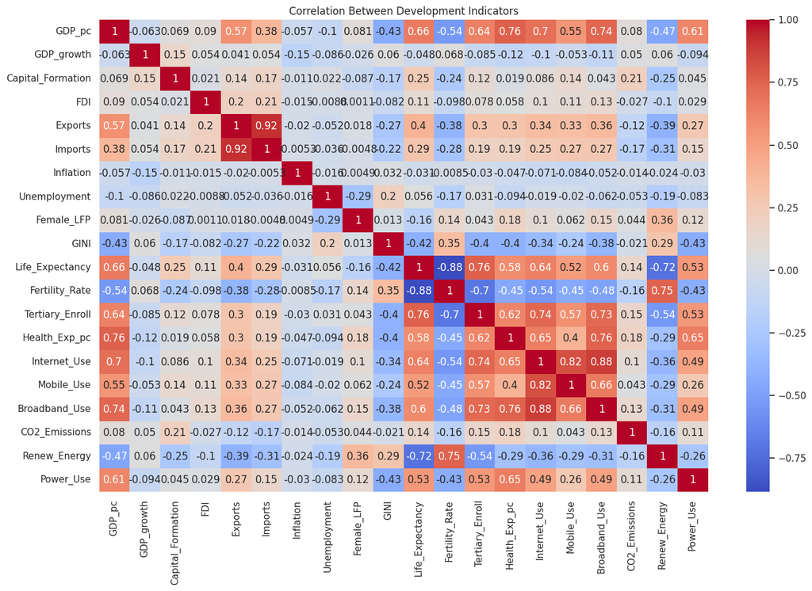

```python
plt.figure(figsize=(16, 10))
sns.heatmap(df_filtered_1990_2023[features].corr(), annot=True, cmap="coolwarm")
plt.title("Correlation Between Development Indicators")
plt.show()
```

**Interpretation of Correlation Between Development Indicators**

The correlation matrix reveals the strength and direction of linear relationships between global development indicators (from –1 to +1). Red = strong positive, blue = strong negative.

**Economic Indicators**

| Pair | Correlation | Interpretation |
| --- | --- | --- |
| **GDP_pc <-> Exports** | **0.57** | Wealthier countries tend to have larger export shares. Reflects industrial capacity and global integration. |
| **GDP_pc <-> Internet_Use** | **0.70** | Strong link: richer countries have better internet infrastructure and penetration. |
| **GDP_pc <-> Health_Exp_pc** | **0.76** | High-income nations spend more on health per capita, consistent with World Bank findings. |
| **GDP_pc <-> Life_Expectancy** | **0.66** | Higher income correlates with better health and longevity. |
| **GDP_pc <-> GINI** | **–0.43** | Negative correlation: richer countries tend to have **lower income inequality**. |
| **GDP_growth <-> Others** | Generally **weak correlations** (e.g., max ~0.15) | Implies **growth rate is not tightly linked** to most structural indicators. Likely influenced by volatility, cycles, or shocks. |

**Gender, Labor, and Fertility**

[output not shown]

**Technology and Connectivity**

[output not shown]

**Energy & Emissions**

[output not shown]

**Time Series Trend**

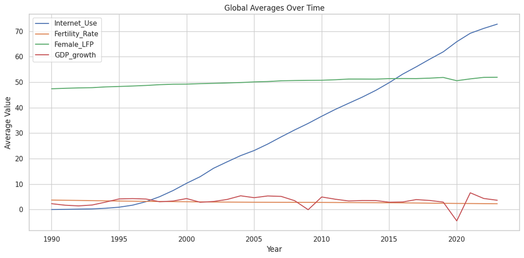

```python
df_time_avg = df_filtered_1990_2023.groupby('Year')[
    ['Internet_Use', 'Fertility_Rate', 'Female_LFP', 'GDP_growth']
].mean().reset_index()

df_time_avg.plot(x='Year', figsize=(12, 6), title="Global Averages Over Time")
plt.ylabel("Average Value")
plt.grid(True)
plt.tight_layout()
plt.show()
```

**Time Trend Interpretation: Global Averages Over Time (1990–2023)**

This line chart shows the average yearly trend (across all countries) of:

**Internet_Use (Blue Line) – Exponential Growth**

- Rapid and consistent rise from near-zero in 1990 to over 70% by 2023 globally.
- Reflects global digital transformation, mobile tech diffusion, and infrastructure investments.
- Most significant change among the indicators, suggesting its strong influence on modern development trends.

**Implication:** Internet penetration likely plays a key role in driving outcomes such as lower fertility, higher education access, and labor market changes.

**Female_LFP (Green Line) – Gradual Increase**

- Began around 47% in 1990, slowly increased to just over 52% by 2023.
- Shows modest global progress in female labor inclusion over three decades.
- Slight dip around 2020, likely due to COVID-19’s disproportionate impact on women in labor markets.

**Implication:** Despite progress, gender gaps in employment persist; stronger policies may be needed to accelerate inclusion.

**Fertility_Rate (Orange Line) – Steady Decline**

**Implication:** Fertility decline aligns with rising education and internet access. This relationship is central to your regression analysis.

**GDP_growth (Red Line) – Fluctuating & Volatile**

- Highly cyclical pattern with visible recessions in 2009 and 2020.
- 2009: Global Financial Crisis
- 2020: COVID-19 Shock (notably sharp drop into negative territory)
- Otherwise ranges between 2%–5%, showing some post-shock recoveries.

**Implication:** Growth trends are volatile and influenced by global crises more than slow-moving development variables.

**Outlier Detection Using Z-Scores**

```python
from scipy.stats import zscore

# Compute Z-scores for highly skewed vars
z_scores = df_filtered_1990_2023[['FDI', 'Inflation', 'GDP_growth']].apply(zscore)

# Find rows with z > 3
outliers = (z_scores.abs() > 3).any(axis=1)
print(f"Number of outlier rows: {outliers.sum()}")
df_filtered_1990_2023[outliers].head(95)
```

```
Number of outlier rows: 95
```

|  | Country Name | Country Code | Year | GDP_pc | GDP_growth | Capital_Formation | FDI | Exports | Imports | Inflation | ... | Health_Exp_pc | Internet_Use | Mobile_Use | Broadband_Use | CO2_Emissions | Renew_Energy | Power_Use | GDP_volatility | Internet_Use_Lag1 | Fertility_Category |
| --- | --- | --- | --- | --- | --- | --- | --- | --- | --- | --- | --- | --- | --- | --- | --- | --- | --- | --- | --- | --- | --- |
| 1 | Albania | ALB | 1991 | 1908.941778 | -28.002142 | 7.603111 | 3.066662 | 7.484819 | 28.585701 | 226.005421 | ... | 65.476746 | 0.00224 | 0.000000 | 0.008842 | 4.3795 | 33.0 | 418.453589 | 13.029504 | 0.000000 | Medium |
| 102 | Armenia | ARM | 1990 | 2760.249500 | -11.699998 | 44.345061 | 0.188555 | 35.002982 | 46.332737 | 3373.759443 | ... | 25.660637 | 0.00000 | 0.000000 | 0.000195 | 20.7801 | 2.1 | 2711.895517 | 3.568118 | 26.983341 | Medium |
| 103 | Armenia | ARM | 1991 | 2476.603092 | -11.699998 | 28.472832 | 0.188555 | 40.745388 | 60.120467 | 3373.759443 | ... | 25.660637 | 0.00228 | 0.000000 | 0.000195 | 21.5981 | 2.3 | 2608.760377 | 0.000000 | 0.000000 | Medium |
| 104 | Armenia | ARM | 1992 | 1491.612672 | -41.800003 | 17.066959 | 0.188555 | 39.820755 | 61.256004 | 3373.759443 | ... | 25.660637 | 0.00456 | 0.000000 | 0.000195 | 10.9766 | 6.7 | 1891.730949 | 17.378246 | 0.002280 | Medium |
| 105 | Armenia | ARM | 1993 | 1440.393678 | -8.799999 | 12.455404 | 0.066594 | 47.218976 | 60.754170 | 3373.759443 | ... | 25.660637 | 0.00684 | 0.000000 | 0.000195 | 5.1153 | 12.9 | 1163.803538 | 15.593377 | 0.004560 | Medium |
| ... | ... | ... | ... | ... | ... | ... | ... | ... | ... | ... | ... | ... | ... | ... | ... | ... | ... | ... | ... | ... | ... |
| 3187 | Sierra Leone | SLE | 2015 | 2508.487131 | -20.491074 | 9.873229 | 3.795099 | 12.280489 | 30.088361 | 6.689436 | ... | 118.660240 | 6.34000 | 77.336645 | 0.002225 | 1.0144 | 74.0 | 306.284485 | 15.915794 | 6.060000 | High |
| 3505 | Togo | TGO | 1993 | 924.562672 | -15.095827 | 13.396113 | -1.066389 | 17.474422 | 25.238078 | -1.006882 | ... | 10.636394 | 0.00000 | 0.000000 | 0.019408 | 0.4108 | 91.5 | 67.023922 | 6.930073 | 0.000000 | High |
| 3787 | Zimbabwe | ZWE | 2003 | 1758.500458 | -16.995075 | 13.813762 | 0.066346 | 32.397059 | 38.054929 | 3.022670 | ... | 94.448097 | 1.80000 | 3.011396 | 0.052206 | 10.8569 | 78.0 | 861.651544 | 7.408747 | 1.100000 | Medium |
| 3792 | Zimbabwe | ZWE | 2008 | 1290.247885 | -17.668946 | 3.285910 | 1.168557 | 41.466849 | 68.054788 | 3.022670 | ... | 94.448097 | 3.50000 | 13.184662 | 0.138898 | 8.2235 | 81.6 | 599.807904 | 5.922239 | 3.000000 | Medium |
| 3794 | Zimbabwe | ZWE | 2010 | 1734.485559 | 21.452061 | 17.011730 | 1.018022 | 29.640895 | 53.483295 | 3.022670 | ... | 94.448097 | 6.40000 | 59.969922 | 0.247070 | 10.0650 | 81.2 | 576.795741 | 15.224039 | 4.000000 | High |

95 rows × 26 columns

**Note on Outliers**

For the outliers we carefully considered it based on their nature and impact on the regression model.

Scaling elimiantes the effect of outliers where use of the scaled dataset is preferably, such as when it comes to clustering.

## Clustering

Clustering is unsupervised learning, meaning we do not have a target variable, but we rather seek to gain a better understnading of the variables in our data.

We will aim to answer the following questions:

- Question 1: How can we discover hidden socioeconomic development based on trade openness (exports, imports), internet/mobile penetration, and tertiary enrolment?
- Question 2: Do countries cluster into distinct groups based on environmental and energy indicators (CO₂ emissions levels/trends, renewable energy % of use, and per capita energy consumption) along with economic size?
- Question 3: How have clusters changed over time? (revisiting the topics discussed in Questions 1 and 2)

## Question 1: How can we discover hidden socioeconomic development based on trade openness, internet/mobile penetration, and tertiary enrolment?

One dilemma that arises is how to treat the decaded of time-series data for this analysis. Among the apporaches considered was the analysis of changes over time, e.g. via using the delta of the relevant variables for clustering. While this would show us (via the scaled data) which countries advanced or fell behind others, it would not differentiate between those seemingly "stagnating" countries that consistently remained in the forefront, versus those that ramained in the back - and those in between. Here, scaled data would also fail to show absolute changes over time, only the relative.

While such an analysis could be fruitful when combining/cross-referencing the changes with snapshots and the scaled with the unscaled data, for the sake of simplicity, we shall first examine a snapshot of the most recent year, 2023. This naturally biases us to the present and ignores changes over the years (tendencies, trajectories, which countries changed most). Why will be patrially rectified in following sections (e.g. by comparing 2023 to our earliest retained data, 1990).

First using our 2023 snapsgot data, we shall filter for five indicators 'Exports', 'Imports', 'Internet_Use', 'Mobile_Use', 'Tertiary_Enroll', that is:

- Exports of goods and services (% of GDP)
- Imports of goods and services (% of GDP)
- Individuals using the Internet (% of population)
- Mobile cellular subscriptions (per 100 people)
- School enrollment, tertiary (% gross)

Out data contains 23 indicators (all numeric, hence fit for clustering without adjustment in this regard), and not all of them are directly relevant for the topic as hand (i.e. CO2 emissions). As there is no automated methods what would eliminate these for clustering (no target variable they could predict), the relevant variables were selected manually.

```python
import pandas as pd
import matplotlib.pyplot as plt
from sklearn.metrics import silhouette_score
from sklearn.metrics import davies_bouldin_score
from sklearn.cluster import KMeans
from sklearn.decomposition import PCA

# Load the 2023 snapshot of scaled data
snapshot = df_scaled_1990_2023[df_scaled_1990_2023['Year'] == df_scaled_1990_2023['Year'].max()]

# Select features of interest
features = snapshot[['Exports', 'Imports', 'Internet_Use', 'Mobile_Use', 'Tertiary_Enroll']]
```

Next, we aim to determine the optimal number of clusters to specifiy before running K-Means clustering. We shall use all of the following methods, comprare the output for different numbers of clusters, and see if they point in similar directions:

- Within-sum-of-squares -> Elbow method
- Silhouette Index
- Davies-Bouldin Score

Naturally, we are looking for the optimal trade-off, where out clusters are not too homogenous but our output is complex enough to have specificity in describing the patterns of countries. There is no single objective corrent solution, hence we shall "eyeball" the output of the three methods.

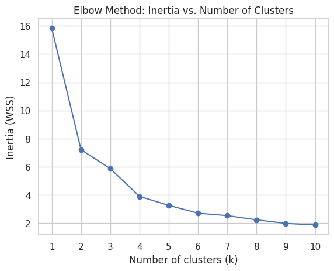

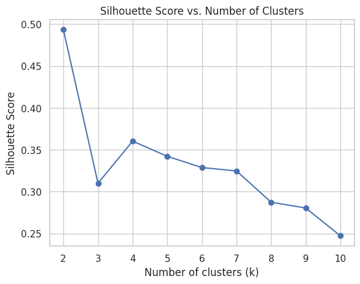

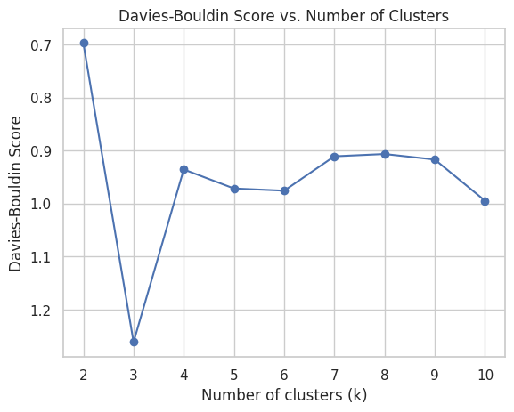

```python
# Compute inertia (WSS) for k = 1 to 10
inertias = []
for k in range(1, 11):
    km = KMeans(n_clusters=k, random_state=42)
    km.fit(features)
    inertias.append(km.inertia_)

# Plot the Elbow curve
plt.figure()
plt.plot(range(1, 11), inertias, marker='o')
plt.title('Elbow Method: Inertia vs. Number of Clusters')
plt.xlabel('Number of clusters (k)')
plt.ylabel('Inertia (WSS)')
plt.xticks(range(1, 11))
plt.show()

# Compute silhouette scores for k = 2 to 10
sil_scores = []
ks = range(2, 11)
for k in ks:
    km = KMeans(n_clusters=k, random_state=42)
    labels = km.fit_predict(features)
    sil_scores.append(silhouette_score(features, labels))

# Plot the Silhouette score curve
plt.figure()
plt.plot(ks, sil_scores, marker='o')
plt.title('Silhouette Score vs. Number of Clusters')
plt.xlabel('Number of clusters (k)')
plt.ylabel('Silhouette Score')
plt.xticks(ks)
plt.show()

# Compute Davies-Bouldin scores for k = 2 to 10
db_scores = []
ks = range(2, 11)
for k in ks:
    km = KMeans(n_clusters=k, random_state=42)
    labels = km.fit_predict(features)
    db_scores.append(davies_bouldin_score(features, labels))

# Plot the Davies-Bouldin score curve
plt.figure()
plt.plot(ks, db_scores, marker='o')
plt.title('Davies-Bouldin Score vs. Number of Clusters')
plt.xlabel('Number of clusters (k)')
plt.ylabel('Davies-Bouldin Score')
plt.xticks(ks)
plt.gca().invert_yaxis()
plt.show()
```

Interpretation:

- Elbow (Inertia): continues a substantial reduction through k=4k.
- Silhouette has a clear local maximum at k=4.
- Davies–Bouldin also shows a slight local minimum at k=4.

Whilke the 2 latter methods would prefer 2 clusters, we are looking to add a bit more to our model (otherwise it is like to merely split developed and not-so-developed nations with not middle ground). The methods align in indicating that 4 clusters would be a good fit for the analysis, hence we shall go with k = 4.

With this, we can go ahead and perform K-Means clustering on the 2023 snapshot of our five indicators. As missing values were previously addressed, they will not be an issue for K-Means.

```
Cluster Sizes:
   Cluster  Size
0        0    30
1        1    42
2        2    34
3        3     6

Cluster Centers (scaled features):
   Cluster   Exports   Imports  Internet_Use  Mobile_Use  Tertiary_Enroll
0        0  0.083818  0.136092      0.356867    0.234184         0.067580
1        1  0.161048  0.187981      0.804643    0.298484         0.265860
2        2  0.183897  0.184944      0.921794    0.296592         0.533262
3        3  0.582698  0.552454      0.949000    0.387733         0.472377
```

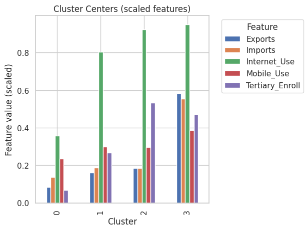

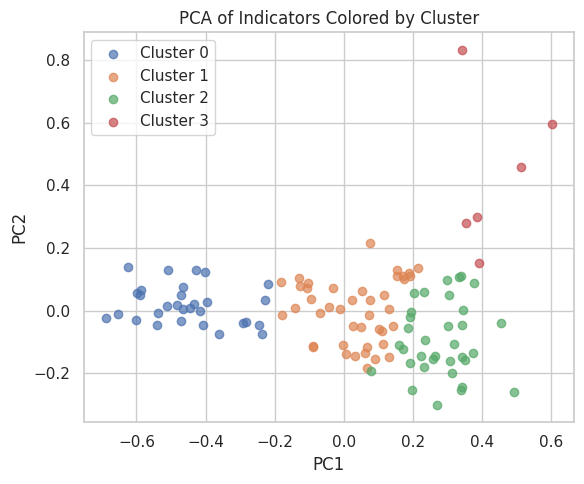

```python
# Fit K-Means with k=4
k = 4
kmeans = KMeans(n_clusters=k, random_state=42)
snapshot.loc[:, 'Cluster'] = kmeans.fit_predict(features)

# SDisplay cluster sizes
cluster_sizes = snapshot['Cluster'].value_counts().sort_index().reset_index()
cluster_sizes.columns = ['Cluster', 'Size']
print("Cluster Sizes:")
print(cluster_sizes)

# Display cluster centers (scaled feature means)
centers = pd.DataFrame(kmeans.cluster_centers_, columns=features.columns)
centers['Cluster'] = centers.index
centers = centers[['Cluster'] + list(features.columns)]
print("\nCluster Centers (scaled features):")
print(centers)

# Plot cluster centers for visual comparison
plt.figure(figsize=(8, 5))
centers_plot = centers.set_index('Cluster')
centers_plot.plot(kind='bar')
plt.title('Cluster Centers (scaled features)')
plt.xlabel('Cluster')
plt.ylabel('Feature value (scaled)')
plt.legend(title='Feature', bbox_to_anchor=(1.05, 1), loc='upper left')
plt.tight_layout()
plt.show()

# PCA for 2D visualization (only a 2D summary/appproximation of our 5D analysis)
pca = PCA(n_components=2)
pca_result = pca.fit_transform(features)
snapshot.loc[:, 'PC1'] = pca_result[:, 0]
snapshot.loc[:, 'PC2'] = pca_result[:, 1]

plt.figure(figsize=(6, 5))
for cluster in sorted(snapshot['Cluster'].unique()):
    mask = snapshot['Cluster'] == cluster
    plt.scatter(snapshot.loc[mask, 'PC1'], snapshot.loc[mask, 'PC2'], label=f'Cluster {cluster}', alpha=0.7)
plt.title('PCA of Indicators Colored by Cluster')
plt.xlabel('PC1')
plt.ylabel('PC2')
plt.legend()
plt.tight_layout()
plt.show()
```

Let us list which countries belong in which clusters.

It is to be noted that we do not have continents/regions assigned to the countries. While we could join this data from other sources, we prefer to retain a region-agnostic analysis in this case.

```python
clustered = snapshot.groupby('Cluster')['Country Name'].apply(list)

for cluster, countries in clustered.items():
    n = len(countries)
    cols = 4
    rows = (n + cols - 1) // cols
    matrix = []
    for r in range(rows):
        row = []
        for c in range(cols):
            idx = c * rows + r
            row.append(countries[idx] if idx < n else "")
        matrix.append(row)

    print(f"Cluster {cluster} ({n} countries):")
    for row in matrix:
        print("  ".join(f"{item:20}" for item in row))
    print()
```

```
Cluster 0 (30 countries):
Bangladesh            Cote d'Ivoire         Madagascar            Sierra Leone
Benin                 Gambia, The           Mali                  Sri Lanka
Burkina Faso          Guatemala             Mauritania            Tanzania
Burundi               Guinea                Nepal                 Togo
Cameroon              Guinea-Bissau         Niger                 Uganda
Chad                  Honduras              Pakistan              Zimbabwe
Comoros               India                 Rwanda
Congo, Rep.           Kenya                 Senegal

Cluster 1 (42 countries):
Albania               Costa Rica            Japan                 Panama
Algeria               Dominican Republic    Jordan                Paraguay
Armenia               Ecuador               Kyrgyz Republic       Peru
Bahamas, The          Egypt, Arab Rep.      Malaysia              Philippines
Belize                El Salvador           Mauritius             Romania
Bolivia               Gabon                 Mexico                South Africa
Botswana              Ghana                 Mongolia              Thailand
Brazil                Hungary               Morocco               Tunisia
Brunei Darussalam     Indonesia             Namibia               Viet Nam
Cabo Verde            Iran, Islamic Rep.    Nicaragua
Colombia              Israel                North Macedonia

Cluster 2 (34 countries):
Argentina             China                 Italy                 Spain
Australia             Czechia               Korea, Rep.           Sweden
Austria               Denmark               Macao SAR, China      Switzerland
Bahrain               Finland               Netherlands           Turkiye
Belarus               France                New Zealand           United Kingdom
Belgium               Georgia               Norway                United States
Bulgaria              Germany               Portugal              Uruguay
Canada                Greece                Saudi Arabia
Chile                 Iceland               Slovenia

Cluster 3 (6 countries):
Cyprus                Ireland               Malta
Hong Kong SAR, China  Luxembourg            Singapore
```

### Interpreting clusters

Let us see if we can weave coherent a narrative concerning that we see and name the clusters accordingly.

Cluster 0 (30 countries) – “Lower-Performers”

- All five indicators are below average.
- These economies have yet to really scale up trade, connectivity, or higher-education enrollment.

Cluster 1 (42 countries) – “Balanced Mid-Performers”

- Moderate trade openness and good digital adoption, but tertiary enrollment still middling.
- Emerging economies that have laid digital and trade foundations but need to boost human-capital investment.

Cluster 2 (34 countries) – “Digital & Educational Leaders”

- Top-tier Internet and tertiary enrollment, with solid (though not top) trade openness.
- Nations that have prioritized human capital and connectivity, now poised to deepen trade links.

Cluster 3 (6 countries) – “High Flyers”

### Conclusion

While GDP-based rankings place all high-income economies together, our clustering teases out who leads in digital adoption versus who leads in trade or education.

Policy peer groups:

- A country in Cluster 2 (Digital & Educational Leader) but mid-rank in GDP might learn best practices in trade from Cluster 3.
- A Cluster 1 economy could compare its tertiary-enrollment policies with Cluster 2 peers to close the education gap.

Targeted diagnostics:

- Cluster 0 nations need broad interventions—trade facilitation, digital infrastructure, and university capacity building.
- Cluster 1 should shift emphasis toward higher education, and Cluster 2 toward expanding global trade ties.

### Hierarchical clustering approach

While we will be sticking to the K-Means method going forward, to have some methodological variance, we will briefly rerun this exercise using hierarchical clustering (which itself determines the number of clusters) and comprare the output.

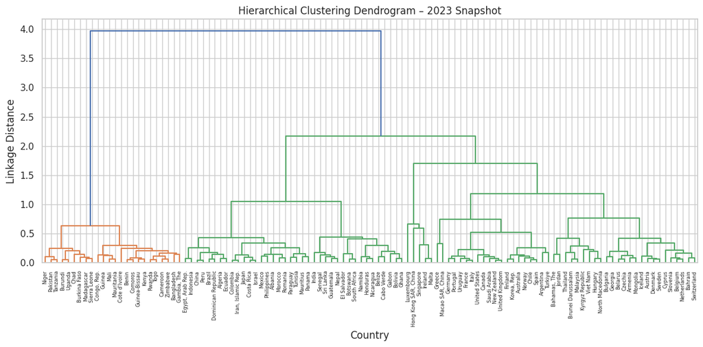

```python
from scipy.cluster.hierarchy import linkage, dendrogram, fcluster

L = linkage(features, method='ward')

# Plot dendrogram
plt.figure(figsize=(12, 6))
dendrogram(
    L,
    labels=snapshot['Country Name'].values,
    leaf_rotation=90,
    leaf_font_size=6
)
plt.title("Hierarchical Clustering Dendrogram – 2023 Snapshot")
plt.xlabel("Country")
plt.ylabel("Linkage Distance")
plt.tight_layout()
plt.show()
```

The dendrogram shows splits at various levels of the hierarchy. The main split and coloring corresponds to the 2 clusters certain metrics also suggested for out previous analysis, with pooper countries seemingly in the ornage cluster, while the green one is quite diverse, encompassing Indonecia to Nepal to Switzerland (the latter two mountainous!). While the groups can be further split, I believe the four clusters previously arrived at provide a satisfactory overview.

## Question 2: Do countries cluster into distinct groups based on environmental and energy indicators along with economic size?

The 2023 (most recent) snapshot from question 1 will also serve us well for this exercise, thus we will reuse it, selecting different features as appropriate.

Here we will include indicators 'CO2_Emissions', 'Renew_Energy', 'Power_Use', 'GDP_pc' in our analysis, the latter capturing the size of the economy, the others emissions and energy-related metrics.

Afted this, we determine the optimal number of clusters using the same methodology as previously.

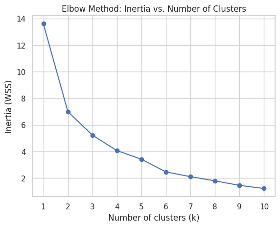

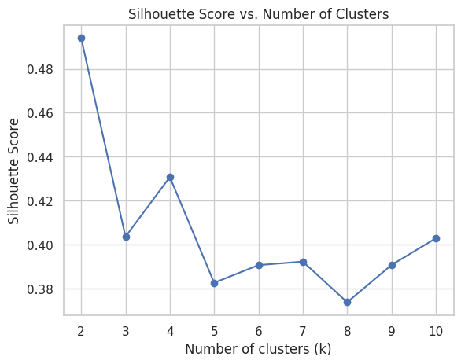

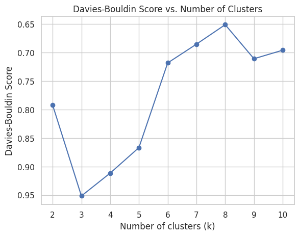

```python
# Select environmental, energy, and economic size features
features_env = snapshot[['CO2_Emissions', 'Renew_Energy', 'Power_Use', 'GDP_pc']]

# Compute inertia (WSS) for k = 1 to 10
inertias = []
for k in range(1, 11):
    km = KMeans(n_clusters=k, random_state=42)
    km.fit(features_env)
    inertias.append(km.inertia_)

# Plot the Elbow curve
plt.figure()
plt.plot(range(1, 11), inertias, marker='o')
plt.title('Elbow Method: Inertia vs. Number of Clusters')
plt.xlabel('Number of clusters (k)')
plt.ylabel('Inertia (WSS)')
plt.xticks(range(1, 11))
plt.show()

# Compute silhouette scores for k = 2 to 10
sil_scores = []
ks = range(2, 11)
for k in ks:
    km = KMeans(n_clusters=k, random_state=42)
    labels = km.fit_predict(features_env)
    sil_scores.append(silhouette_score(features_env, labels))

# Plot the Silhouette score curve
plt.figure()
plt.plot(ks, sil_scores, marker='o')
plt.title('Silhouette Score vs. Number of Clusters')
plt.xlabel('Number of clusters (k)')
plt.ylabel('Silhouette Score')
plt.xticks(ks)
plt.show()

# Compute Davies-Bouldin scores for k = 2 to 10
db_scores = []
ks = range(2, 11)
for k in ks:
    km = KMeans(n_clusters=k, random_state=42)
    labels = km.fit_predict(features_env)
    db_scores.append(davies_bouldin_score(features_env, labels))

# Plot the Davies-Bouldin score curve
plt.figure()
plt.plot(ks, db_scores, marker='o')
plt.title('Davies-Bouldin Score vs. Number of Clusters')
plt.xlabel('Number of clusters (k)')
plt.ylabel('Davies-Bouldin Score')
plt.xticks(ks)
plt.gca().invert_yaxis()
plt.show()
```

While it is less clear than previously, k=4 is still a potential sweetspot for the number of clusters.

- Elbow point: around k=3–4
- Silhouette peaks at k=2, but the next local maximum is at k=4
- Davies–Bouldin: while the score decreases beyond 4 clusters (most sharply at 6), 4 remains acceptable given the other methods as not to bloat the number of clusters

```
Cluster Sizes:
   Cluster  Size
0        0    49
1        1     4
2        2    28
3        3    31

Cluster Centers (scaled features):
   Cluster  CO2_Emissions  Renew_Energy  Power_Use    GDP_pc
0        0       0.014112      0.217265   0.042131  0.114146
1        1       0.002165      0.640641   0.454192  0.422162
2        2       0.000620      0.711343   0.009143  0.036909
3        3       0.057026      0.141437   0.145703  0.390727
```

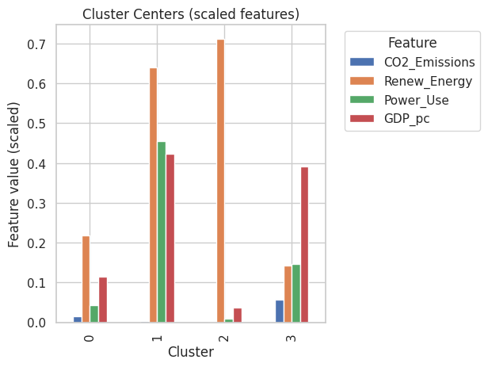

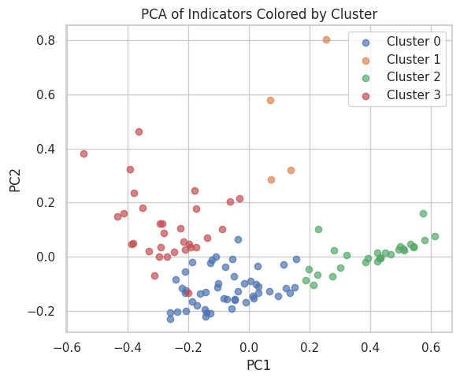

```python
# Fit K-Means with k=4
k = 4
kmeans = KMeans(n_clusters=k, random_state=42)
snapshot.loc[:, 'Cluster'] = kmeans.fit_predict(features_env)

# SDisplay cluster sizes
cluster_sizes = snapshot['Cluster'].value_counts().sort_index().reset_index()
cluster_sizes.columns = ['Cluster', 'Size']
print("Cluster Sizes:")
print(cluster_sizes)

# Display cluster centers (scaled feature means)
centers = pd.DataFrame(kmeans.cluster_centers_, columns=features_env.columns)
centers['Cluster'] = centers.index
centers = centers[['Cluster'] + list(features_env.columns)]
print("\nCluster Centers (scaled features):")
print(centers)

# Plot cluster centers for visual comparison
plt.figure(figsize=(8, 5))
centers_plot = centers.set_index('Cluster')
centers_plot.plot(kind='bar')
plt.title('Cluster Centers (scaled features)')
plt.xlabel('Cluster')
plt.ylabel('Feature value (scaled)')
plt.legend(title='Feature', bbox_to_anchor=(1.05, 1), loc='upper left')
plt.tight_layout()
plt.show()

# PCA for 2D visualization
pca = PCA(n_components=2)
pca_result = pca.fit_transform(features_env)
snapshot.loc[:, 'PC1'] = pca_result[:, 0]
snapshot.loc[:, 'PC2'] = pca_result[:, 1]

plt.figure(figsize=(6, 5))
for cluster in sorted(snapshot['Cluster'].unique()):
    mask = snapshot['Cluster'] == cluster
    plt.scatter(snapshot.loc[mask, 'PC1'], snapshot.loc[mask, 'PC2'], label=f'Cluster {cluster}', alpha=0.7)
plt.title('PCA of Indicators Colored by Cluster')
plt.xlabel('PC1')
plt.ylabel('PC2')
plt.legend()
plt.tight_layout()
plt.show()
```

Once again, let us list the countries per cluster:

```python
clustered = snapshot.groupby('Cluster')['Country Name'].apply(list)

for cluster, countries in clustered.items():
    n = len(countries)
    cols = 4
    rows = (n + cols - 1) // cols
    matrix = []
    for r in range(rows):
        row = []
        for c in range(cols):
            idx = c * rows + r
            row.append(countries[idx] if idx < n else "")
        matrix.append(row)

    print(f"Cluster {cluster} ({n} countries):")
    for row in matrix:
        print("  ".join(f"{item:20}" for item in row))
    print()
```

```
Cluster 0 (49 countries):
Albania               Colombia              Iran, Islamic Rep.    Peru
Algeria               Comoros               Jordan                Philippines
Argentina             Costa Rica            Kyrgyz Republic       Portugal
Armenia               Dominican Republic    Malaysia              Romania
Bangladesh            Ecuador               Mauritania            Senegal
Belarus               Egypt, Arab Rep.      Mauritius             South Africa
Belize                El Salvador           Mexico                Thailand
Bolivia               Georgia               Mongolia              Tunisia
Botswana              Ghana                 Morocco               Turkiye
Brazil                Greece                Namibia               Viet Nam
Bulgaria              Hungary               North Macedonia
Cabo Verde            India                 Pakistan
Chile                 Indonesia             Panama

Cluster 1 (4 countries):
Finland               Iceland               Norway                Sweden

Cluster 2 (28 countries):
Benin                 Gabon                 Madagascar            Sierra Leone
Burkina Faso          Gambia, The           Mali                  Sri Lanka
Burundi               Guatemala             Nepal                 Tanzania
Cameroon              Guinea                Nicaragua             Togo
Chad                  Guinea-Bissau         Niger                 Uganda
Congo, Rep.           Honduras              Paraguay              Uruguay
Cote d'Ivoire         Kenya                 Rwanda                Zimbabwe

Cluster 3 (31 countries):
Australia             Cyprus                Italy                 Saudi Arabia
Austria               Czechia               Japan                 Singapore
Bahamas, The          Denmark               Korea, Rep.           Slovenia
Bahrain               France                Luxembourg            Spain
Belgium               Germany               Macao SAR, China      Switzerland
Brunei Darussalam     Hong Kong SAR, China  Malta                 United Kingdom
Canada                Ireland               Netherlands           United States
China                 Israel                New Zealand
```

### Interpretation:

We may designate the clusters as the following:

Cluster 0: “Mixed Mid-Spectrum”

- Moderate values on all four axes (CO₂≈0.01, Renew≈0.22, Power≈0.04, GDP≈0.11).
- (A broad band of middle-income and emerging markets)
- These countries neither lead nor lag extremely on any one dimension.

Cluster 1: “Nordic/Renewables Leaders”

- Very high renewables share (0.64), high power use (0.45) & GDP (0.42), near-zero CO₂.
- (Countries: Finland, Iceland, Norway, Sweden)
- These small advanced economies pair large energy consumption with clean grids.

Cluster 2: “Emerging Renewables”

- Highest renewables share (0.71) but very low power use (0.01) & GDP (0.04), near-zero CO₂.
- (Mostly lower-income countries in Africa/Latin America)
- They rely heavily on traditional renewables (biomass, hydro) but lack overall energy infrastructure.

Cluster 3: “High Emitters & Consumers”

- Highest CO₂ emissions (0.06), above-average power use (0.15) & GDP (0.39), low renewables (0.14).
- (Major advanced economies & large emitters: US, China, Germany, etc.)
- These are the big industrial/transport hubs with heavy fossil-fuel footprints.

### Conclusion:

The split raptures policy-relevant divides between green leaders, low-income renewables users, fossil-fuel–driven giants, and the broad middle. Each group suggests different priorities—e.g., carbon reduction for Cluster 3, infrastructure build-out for Cluster 2, and scaling clean capacity for Cluster 0.

## Question 3: How have clusters changed over time?

For this point, we shall examine whether the clusters we indetified are consistent and hold up against time. As it is exceedingly challenging to examine a time series year-after-year via clustering and retain a consistent narrative, especially due to the randomness inherent in the k we shall revisit snapshots from the first two question, but instead of looking at our most recent data (2023), we shall look at the oldest data we have retained (1990) and examine how things have hcnged in 33 years. The methodology will remain identical to that previously used with the snapshots for the sake of comparability.

Is should be noted that the 1990 might be less reliable, more imputation is expected, and collection moethodologies may have changed locally over 33 years especially in developing countries.

### Socioeconomic development (Question 1 revisited)

Retaining k=4, we shall rerun the K-Means clustering from question 1 with indicators from 1990 instead of 2023, and exampine how things changed in 33 years.

It is to be noted that while retaining four clusters introduces a bias "from the future", and rerunning our previous analyses might point towards a different optimal cluster number for the 1990 data, retaining 4 helps comparability - we shall see if the narratives established fit these new four clusters, or whether they are different beasts entirely.

```
Cluster Sizes:
   Cluster  Size
0        0    15
1        1    62
2        2    34
3        3     1

Cluster Centers (scaled features):
   Cluster   Exports   Imports  Internet_Use  Mobile_Use  Tertiary_Enroll
0        0  0.280460  0.305725  6.733333e-07    0.001040         0.090701
1        1  0.086486  0.117734 -3.794708e-19    0.000045         0.040697
2        2  0.106489  0.121423  1.479853e-03    0.002641         0.204030
3        3  0.674519  0.694905  0.000000e+00    0.004067         0.503014
```

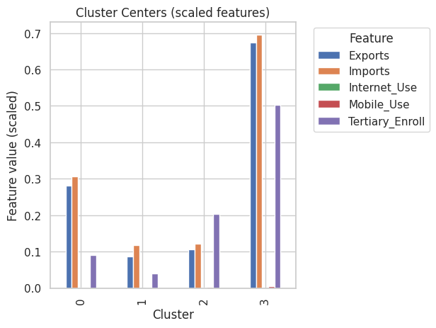

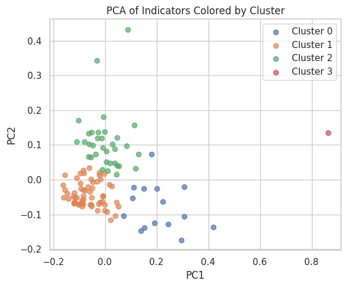

```python
# Filter the scaled dataset for 1990
snapshot90 = df_scaled_1990_2023[df_scaled_1990_2023['Year'] == df_scaled_1990_2023['Year'].min()]

# Select features of interest
features = snapshot90[['Exports', 'Imports', 'Internet_Use', 'Mobile_Use', 'Tertiary_Enroll']]

# Fit K-Means with k=4
k = 4
kmeans = KMeans(n_clusters=k, random_state=42)
snapshot90.loc[:, 'Cluster'] = kmeans.fit_predict(features)

# Display cluster sizes
cluster_sizes = snapshot90['Cluster'].value_counts().sort_index().reset_index()
cluster_sizes.columns = ['Cluster', 'Size']
print("Cluster Sizes:")
print(cluster_sizes)

# Display cluster centers/centroids (scaled feature means)
centers = pd.DataFrame(kmeans.cluster_centers_, columns=features.columns)
centers['Cluster'] = centers.index
centers = centers[['Cluster'] + list(features.columns)]
print("\nCluster Centers (scaled features):")
print(centers)

# Plot cluster centers (centroids) for visual comparison
plt.figure(figsize=(8, 5))
centers_plot = centers.set_index('Cluster')
centers_plot.plot(kind='bar')
plt.title('Cluster Centers (scaled features)')
plt.xlabel('Cluster')
plt.ylabel('Feature value (scaled)')
plt.legend(title='Feature', bbox_to_anchor=(1.05, 1), loc='upper left')
plt.tight_layout()
plt.show()

# PCA for 2D visualization
pca = PCA(n_components=2)
pca_result = pca.fit_transform(features)
snapshot90.loc[:, 'PC1'] = pca_result[:, 0]
snapshot90.loc[:, 'PC2'] = pca_result[:, 1]

plt.figure(figsize=(6, 5))
for cluster in sorted(snapshot90['Cluster'].unique()):
    mask = snapshot90['Cluster'] == cluster
    plt.scatter(snapshot90.loc[mask, 'PC1'], snapshot90.loc[mask, 'PC2'], label=f'Cluster {cluster}', alpha=0.7)
plt.title('PCA of Indicators Colored by Cluster')
plt.xlabel('PC1')
plt.ylabel('PC2')
plt.legend()
plt.tight_layout()
plt.show()
```

```python
clustered = snapshot90.groupby('Cluster')['Country Name'].apply(list)

for cluster, countries in clustered.items():
    n = len(countries)
    cols = 4
    rows = (n + cols - 1) // cols
    matrix = []
    for r in range(rows):
        row = []
        for c in range(cols):
            idx = c * rows + r
            row.append(countries[idx] if idx < n else "")
        matrix.append(row)

    print(f"Cluster {cluster} ({n} countries):")
    for row in matrix:
        print("  ".join(f"{item:20}" for item in row))
    print()
```

```
Cluster 0 (15 countries):
Bahamas, The          Cyprus                Luxembourg            Mauritius
Bahrain               Gambia, The           Macao SAR, China      Panama
Belgium               Hong Kong SAR, China  Malaysia              Slovenia
Botswana              Jordan                Malta

Cluster 1 (62 countries):
Albania               Congo, Rep.           Kenya                 Rwanda
Algeria               Cote d'Ivoire         Madagascar            Saudi Arabia
Bangladesh            Czechia               Mali                  Senegal
Belize                Ecuador               Mauritania            Sierra Leone
Benin                 Egypt, Arab Rep.      Mexico                South Africa
Bolivia               El Salvador           Mongolia              Sri Lanka
Brazil                Gabon                 Morocco               Tanzania
Brunei Darussalam     Ghana                 Namibia               Thailand
Burkina Faso          Guatemala             Nepal                 Togo
Burundi               Guinea                Nicaragua             Tunisia
Cabo Verde            Guinea-Bissau         Niger                 Turkiye
Cameroon              Honduras              North Macedonia       Uganda
Chad                  Hungary               Pakistan              Viet Nam
China                 India                 Paraguay              Zimbabwe
Colombia              Indonesia             Portugal
Comoros               Iran, Islamic Rep.    Romania

Cluster 2 (34 countries):
Argentina             Denmark               Israel                Philippines
Armenia               Dominican Republic    Italy                 Spain
Australia             Finland               Japan                 Sweden
Austria               France                Korea, Rep.           Switzerland
Belarus               Georgia               Kyrgyz Republic       United Kingdom
Bulgaria              Germany               Netherlands           United States
Canada                Greece                New Zealand           Uruguay
Chile                 Iceland               Norway
Costa Rica            Ireland               Peru

Cluster 3 (1 countries):
Singapore
```